# Hands-on Session: Reconstructing Past Social Networks from Inscriptions

Petra Hermankova[^1]

Tom Brughmans[^2]

Last updated: 2025-04-01

**This script demonstrates how to convert people and their relationships from Latin inscriptions into a network representation.**

*Event*: **Epigraphy.info IX**, 2-4 April 2025, Aarhus, Denmark. See https://epigraphy.info/workshop_9/ for details.

*DISCLAIMER*: Some code chunks in this script were generated using GenAI (Claude 3.7, free version). The workshop design, the conceptualisation, and the used data were not created by GenAI, but by the authors. The relevant sources of the data, including the text edition and version of metadata of used inscriptions is specified for individual case studies in their respective section. Authors do not claim the authorship of the original epigraphic data, but any errors in the process of identification of individuals and relationships between them can be attributed solely to the authors.

*Authorship declaration*: data selection and curation [PH], execution of code [PH], conceptualisation [PH, TB], delivery [PH, TB], visualisation [PH], theoretical background and additional resources [TB]

# 1 Initial setup

```r
# Install required packages if not already installed
if (!requireNamespace("igraph", quietly = TRUE)) install.packages("igraph")
if (!requireNamespace("dplyr", quietly = TRUE)) install.packages("dplyr")
if (!requireNamespace("ggplot2", quietly = TRUE)) install.packages("ggplot2")
if (!requireNamespace("ggraph", quietly = TRUE)) install.packages("ggraph")
if (!requireNamespace("networkD3", quietly = TRUE)) install.packages("networkD3")
if (!requireNamespace("tidyverse", quietly = TRUE)) install.packages("tidyverse")

# Load required libraries
library(igraph)      # For network creation and analysis
library(dplyr)       # For data manipulation
library(ggplot2)     # For visualization
library(ggraph)      # For advanced network visualization
library(networkD3)   # For interactive visualization
library(tidyverse)   # For data manipulation
```

# 2 Case study 1 - family network of Publis Livius Macer

## 2.1 The inscription and its context

We are going to be working with a real inscription: **Epitaph from S. Ponso Canavese (Transpadana (Regio XI))** from EDH (https://edh.ub.uni-heidelberg.de/edh/inschrift/HD003544)

**Chronological Data**:

- 51 AD – 150 AD (EDH)
- 71 AD - 130 AD (EDR)
- 75 AD - 125 AD (Trismegistos)
- 71 AD - 130 AD (EDCS)

**Transcription** (from EDH):

P(ublius) Livius P(ubli) f(ilius) Macer  
IIvir QDIV sibi et  
Iuniae C(ai) f(iliae) Vetullae uxori  
P(ublio) Livio Macro VIvir(o) avo  
Pinariae Sex(ti) f(iliae) Quartae aviae  
Liviae P(ubli) f(iliae) Pollae amitae  
Vibiae T(iti) f(iliae) Pollae matri t(estamento) f(ieri) i(ussit)

**Translation** (PHer):

Publius Livius Macer, son of Publius,  
duumvir (municipal magistrate) QDIV, [had this monument made] for himself and for Iunia Vetulla, daughter of Gaius, his wife;  
for Publius Livius Macro, sevir (member of a board of six), his grandfather;  
for Pinaria Quarta, daughter of Sextus, his grandmother;  
for Livia Polla, daughter of Publius, his paternal aunt;  
for Vibia Polla, daughter of Titus, his mother; ordered this to be made by testament.

Note: Macer is a Roman cognomen meaning “lean”.

**Images**:

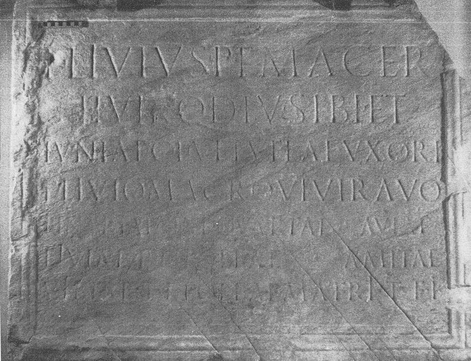

**References**:

- AE 1985, 0479.
- G. Cresci Marrone, BollstorbiblSubalp 83, 1985, 577-579, Nr. 2; Foto 2. - AE 1985.
- CIL 05, 06917. (B)
- https://www.trismegistos.org/text/285446
- http://www.edr-edr.it/edr_programmi/res_complex_comune.php?do=book&id_nr=EDR079871

*Other bibliography:*

- Laes, C. (2024). Amitae and Materterae in Latin Inscriptions. A Contribution to the Study of the Roman Family. Arctos: acta philologica Fennica, 2023(57), 103-155. https://journal.fi/arctos/article/view/146916

## 2.2 Step 1: Identify individuals mentioned in the inscription

```r
# Let's identify each person and assign them an ID
people <- data.frame(
  id = 1:8,
  name = c("Publius Livius Macer",
           "Iunia Vetulla",
           "Publius Livius Macro",
           "Pinaria Quarta",
           "Livia Polla",
           "Vibia Polla",
           "Publius Livius",
           "Gaius"),
  gender = c("male", "female", "male", "female", "female", "female", "male", "male"),
  role = c("commissioner", "wife", "grandfather", "grandmother", "aunt", "mother", "father", "father"),
  status = c("freeborn", "freeborn", "freeborn", "freeborn", "freeborn", "freeborn", "freeborn", "freeborn"),
 generation = c(3, 3, 1, 1, 2, 2, 2, 2),
  stringsAsFactors = FALSE
)

# Print the people we've identified
print(people)
```

```
##   id                 name gender         role   status generation
## 1  1 Publius Livius Macer   male commissioner freeborn          3
## 2  2        Iunia Vetulla female         wife freeborn          3
## 3  3 Publius Livius Macro   male  grandfather freeborn          1
## 4  4       Pinaria Quarta female  grandmother freeborn          1
## 5  5          Livia Polla female         aunt freeborn          2
## 6  6          Vibia Polla female       mother freeborn          2
## 7  7       Publius Livius   male       father freeborn          2
## 8  8                Gaius   male       father freeborn          2
```

## 2.3 Step 2: Identify relationships between these individuals

```r
# Define relationships
relationships <- data.frame(
  from = c(1, 1, 1, 1, 2, 3, 4, 5, 6, 7, 1, 4, 6, 6),
  to = c(2, 3, 4, 7, 8, 1, 1, 1, 1, 1, 6, 3, 7, 5),
  relationship = c("spouse_of", "grandson_of", "grandson_of", "son_of", "daughter_of", "grandfather_of", "grandmother_of", "aunt_of", "mother_of", "father_of", "father_of", "spouse_of", "spouse_of", "sibling_of"),
  certainty = c("certain", "certain", "certain", "certain", "certain", "certain", "certain", "certain", "certain", "certain", "certain", "inferred", "inferred", "inferred"),
  stringsAsFactors = FALSE
)

# Print the relationships we've identified
print(relationships)
```

```
##    from to   relationship certainty
## 1     1  2      spouse_of   certain
## 2     1  3    grandson_of   certain
## 3     1  4    grandson_of   certain
## 4     1  7         son_of   certain
## 5     2  8    daughter_of   certain
## 6     3  1 grandfather_of   certain
## 7     4  1 grandmother_of   certain
## 8     5  1        aunt_of   certain
## 9     6  1      mother_of   certain
## 10    7  1      father_of   certain
## 11    1  6      father_of   certain
## 12    4  3      spouse_of  inferred
## 13    6  7      spouse_of  inferred
## 14    6  5     sibling_of  inferred
```

## 2.4 Step 3: Create the network

```r
# Remove NA relationships for network creation
relationships_clean <- relationships %>%
  filter(!is.na(to))

# Create the graph/network object (using igraph package https://igraph.org/)
inscription_network <- graph_from_data_frame(relationships_clean, directed = TRUE, vertices = people)

# Print basic network information
print(inscription_network)
```

```
## IGRAPH eabc0ed DN-- 8 14 --
## + attr: name (v/c), gender (v/c), role (v/c), status (v/c), generation
## | (v/n), relationship (e/c), certainty (e/c)
## + edges from eabc0ed (vertex names):
##  [1] Publius Livius Macer->Iunia Vetulla
##  [2] Publius Livius Macer->Publius Livius Macro
##  [3] Publius Livius Macer->Pinaria Quarta
##  [4] Publius Livius Macer->Publius Livius
##  [5] Iunia Vetulla       ->Gaius
##  [6] Publius Livius Macro->Publius Livius Macer
##  [7] Pinaria Quarta      ->Publius Livius Macer
## + ... omitted several edges
```

## 2.5 Step 4: Basic visualization

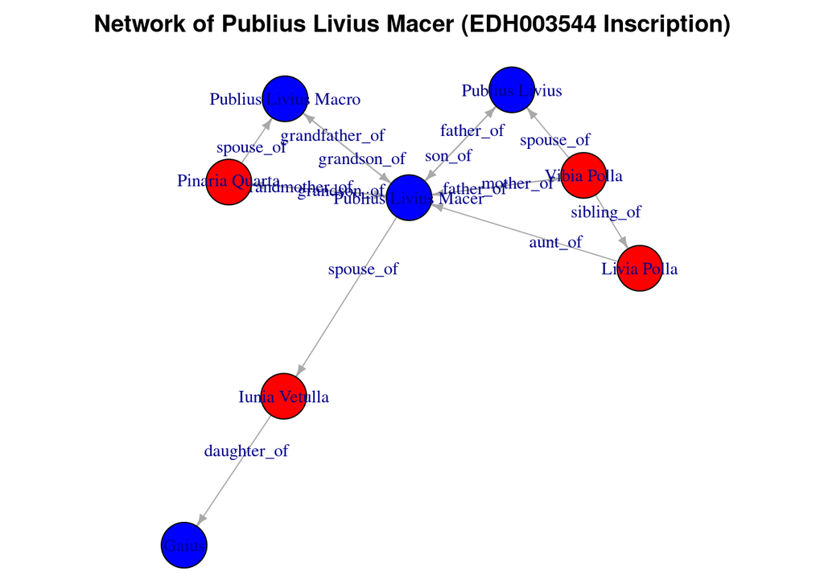

```r
# Visualizing the network using igraph package https://igraph.org/

# Set plot parameters
par(mar = c(0, 0, 2, 0))  # Adjust margins for better visualization

# Plot the network
plot(inscription_network,
     vertex.label = V(inscription_network)$name,
     vertex.color = ifelse(V(inscription_network)$gender == "male", "blue", "red"),
     vertex.size = 20,
     vertex.label.cex = 0.9,
     edge.arrow.size = 0.5,
     edge.label = E(inscription_network)$relationship,
     edge.label.cex = 0.9,
     layout = layout_with_fr(inscription_network),
     main = "Network of Publius Livius Macer (EDH003544 Inscription)")
```

**Food for thought**: Try to run the code again and observe how the visualisation has changed. Why is that so? What does it say about the visualisation?

## 2.6 Step 5: Advanced visualization with ggraph

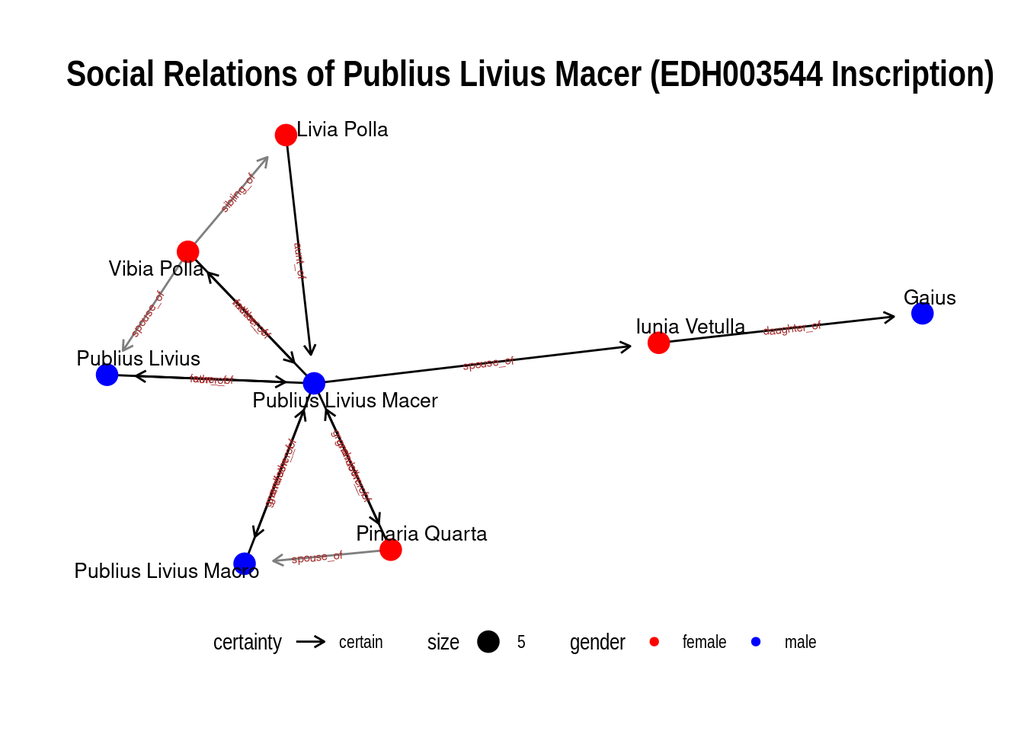

```r
# Different ways to visualise the same data, using ggraph package https://ggraph.data-imaginist.com/

# Create a more sophisticated visualization
inscription_plot <- ggraph(inscription_network, layout = 'fr') +
  geom_edge_link(aes(label = relationship,
                     color = certainty),
                 arrow = arrow(length = unit(2, 'mm')),
                 end_cap = circle(5, 'mm'),
                 angle_calc = 'along',
                 label_size = 2,
                 label_colour = "brown") +
  geom_node_point(aes(color = gender, size = 5)) +
  geom_node_text(aes(label = name), repel = TRUE, size = 3.5) +
  scale_edge_color_manual(values = c("certain" = "black", "uncertain" = "gray90")) +
  scale_color_manual(values = c("male" = "blue", "female" = "red")) +
  theme_graph() +
  ggtitle("Social Relations of Publius Livius Macer (EDH003544 Inscription)") +
  theme(legend.position = "bottom")

# Print the plot
print(inscription_plot)
```

## 2.7 Step 6: Genealogical visualisation

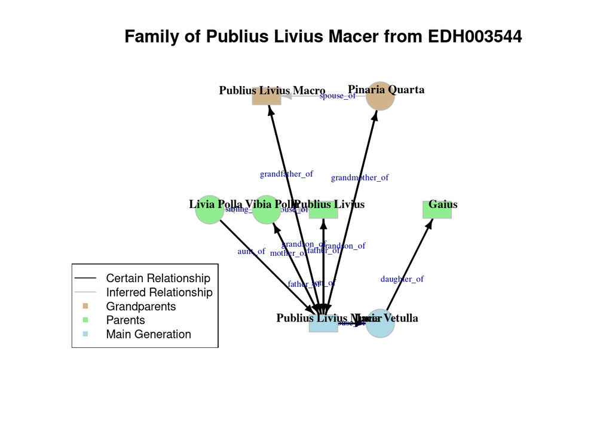

```r
# using igraph package

# Create directed graph
g <- graph_from_data_frame(d = relationships, vertices = people, directed = TRUE)

# Set visual attributes
V(g)$color <- ifelse(V(g)$generation == 1, "tan",
                   ifelse(V(g)$generation == 2, "lightgreen", "lightblue"))
V(g)$shape <- ifelse(V(g)$gender == "female", "circle", "rectangle") #female = circle, male = rectangle
V(g)$label.cex <- 1
E(g)$color <- ifelse(E(g)$certainty == "certain", "black", "gray")
E(g)$width <- ifelse(E(g)$certainty == "certain", 2, 1)
E(g)$arrow.size <- 0.6

# Create a layout with generations properly positioned
# Custom layout to resemble a traditional family tree

### If you are adding new people, don't forget to position them in the matrix - the first number denotes the right to left position, the other one generations, e.g. generation 1: 300, generation 2:200, generation 3: 100
custom_layout <- matrix(c(
  400, 100,  # 1: Publius Livius Macer (main person)
  500, 100,  # 2: Iunia Vetulla (wife)
  300, 300,  # 3: Publius Livius Macro (grandfather)
  500, 300,  # 4: Pinaria Quarta (grandmother)
  200, 200,  # 5: Livia Polla (aunt)
  300, 200,  # 6: Vibia Polla (mother)
  400, 200,  # 7: Publius Livius (father)
  600, 200   # 8: Gaius (father)
), ncol = 2, byrow = TRUE)

# Plot the graph

plot(g, layout = custom_layout,
     edge.label = E(g)$relationship,
     edge.label.dist = 1,
     edge.label.cex = 0.6,
     edge.curved = 0,
     edge.label.color = "darkblue",
     vertex.size = 25,
     vertex.label.color = "black",
     vertex.frame.color = "grey",
     vertex.label.cex = 0.8,
     vertex.label.dist = 1,             # node label size
     vertex.label.font = 2,             # node label type (bold)
     vertex.label = E(g)$name,
     main = "Family of Publius Livius Macer from EDH003544")

legend("bottomleft",
       legend = c("Certain Relationship", "Inferred Relationship",
                 "Grandparents", "Parents", "Main Generation"),
       lty = c(1, 1, NA, NA, NA),
       col = c("black", "gray", "tan", "lightgreen", "lightblue"),
       pch = c(NA, NA, 15, 15, 15),
       cex = 0.8,
       bg = "white")
```

```r
#saving as PNG image into image folder

png("../images/PubliusLiviusMacer_roman_family_tree.png", width = 1200, height = 800, res = 100)
```

## 2.8 Hands-on - add missing poeple and relationships

*Your task is to identify any individuals from the text of the inscription who are missing and add them to the graph, using the script above.*

**The text of the inscription:**

P(ublius) Livius P(ubli) f(ilius) Macer  
IIvir QDIV sibi et  
Iuniae C(ai) f(iliae) Vetullae uxori  
P(ublio) Livio Macro VIvir(o) avo  
Pinariae **Sex(ti)** f(iliae) Quartae aviae  
Liviae P(ubli) f(iliae) Pollae amitae  
Vibiae **T(iti)** f(iliae) Pollae matri t(estamento) f(ieri) i(ussit)

### 2.8.1 Exercise 1: Reconstruct the persons of Sextus and Titus

You can either copy paste the code from above, or create your people and relationships in the spreadsheet and load them back into R. The spreadsheets are located in the `data` folder. Open them with a software of your choice and edit.

#### 2.8.1.1 Step 1: People

```r
# loading a spreadsheet into R

people2 <- read.csv("../data/People_simple.csv")
people2
```

| id | name | gender | role | status | generation |
| --- | --- | --- | --- | --- | --- |
| 1 | Publius Livius Macer | male | commissioner | freeborn | 3 |
| 2 | Iunia Vetulla | female | wife | freeborn | 3 |
| 3 | Publius Livius Macro | male | grandfather | freeborn | 1 |
| 4 | Pinaria Quarta | female | grandmother | freeborn | 1 |
| 5 | Livia Polla | female | aunt | freeborn | 2 |
| 6 | Vibia Polla | female | mother | freeborn | 2 |
| 7 | Publius Livius | male | father | freeborn | 2 |
| 8 | Gaius | male | father | freeborn | 2 |

#### 2.8.1.2 Step 2: Relationships

```r
# loading a spreadsheet into R

relationships2 <- read.csv("../data/Relationships_simple.csv")
relationships2
```

| from | to | relationship | certainty |
| --- | --- | --- | --- |
| 1 | 2 | spouse_of | certain |
| 1 | 3 | grandson_of | certain |
| 1 | 4 | grandson_of | certain |
| 1 | 7 | son_of | certain |
| 2 | 8 | daughter_of | certain |
| 3 | 1 | grandfather_of | certain |
| 4 | 1 | grandmother_of | certain |
| 5 | 1 | aunt_of | certain |
| 6 | 1 | mother_of | certain |
| 7 | 1 | father_of | certain |

[output cut: 4 more lines]

#### 2.8.1.3 Step 3: Create the network

```r
# Remove NA relationships for network creation
relationships_clean2 <- relationships2 %>%
  filter(!is.na(to))

# Create the graph/network object
inscription_network2 <- graph_from_data_frame(relationships_clean2, directed = TRUE, vertices = people2)

# Print basic network information
print(inscription_network2)
```

```
## IGRAPH bb6c0ad DN-- 8 14 --
## + attr: name (v/c), gender (v/c), role (v/c), status (v/c), generation
## | (v/n), relationship (e/c), certainty (e/c)
## + edges from bb6c0ad (vertex names):
##  [1] Publius Livius Macer->Iunia Vetulla
##  [2] Publius Livius Macer->Publius Livius Macro
##  [3] Publius Livius Macer->Pinaria Quarta
##  [4] Publius Livius Macer->Publius Livius
##  [5] Iunia Vetulla       ->Gaius
##  [6] Publius Livius Macro->Publius Livius Macer
##  [7] Pinaria Quarta      ->Publius Livius Macer
## + ... omitted several edges
```

#### 2.8.1.4 Step 4: Visualise the network

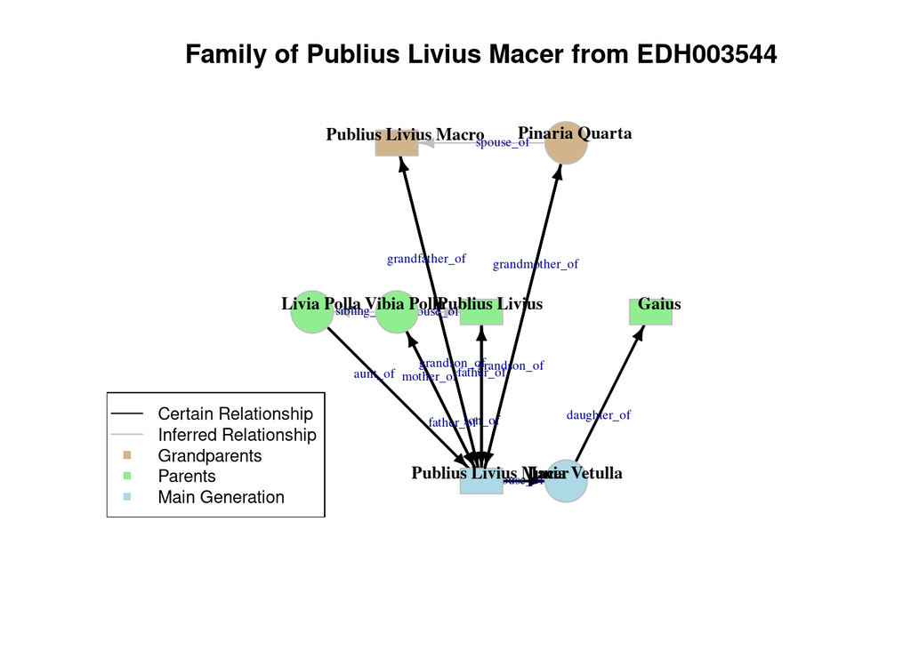

```r
# using igraph package

# Create directed graph
g2 <- graph_from_data_frame(d = relationships2, vertices = people2, directed = TRUE)

# Set visual attributes
V(g2)$color <- ifelse(V(g2)$generation == 1, "tan",
                   ifelse(V(g2)$generation == 2, "lightgreen", "lightblue"))
V(g2)$shape <- ifelse(V(g2)$gender == "female", "circle", "rectangle") #female = circle, male = rectangle
V(g2)$label.cex <- 1
E(g2)$color <- ifelse(E(g2)$certainty == "certain", "black", "gray")
E(g2)$width <- ifelse(E(g2)$certainty == "certain", 2, 1)
E(g2)$arrow.size <- 0.6

# Create a layout with generations properly positioned
# Custom layout to resemble a traditional family tree

### If you are adding new people, don't forget to position them in the matrix - the first number denotes the right to left position, the other one generations, e.g. generation 1: 300, generation 2:200, generation 3: 100

custom_layout <- matrix(c(
  400, 100,  # 1: Publius Livius Macer (main person)
  500, 100,  # 2: Iunia Vetulla (wife)
  300, 300,  # 3: Publius Livius Macro (grandfather)
  500, 300,  # 4: Pinaria Quarta (grandmother)
  200, 200,  # 5: Livia Polla (aunt)
  300, 200,  # 6: Vibia Polla (mother)
  400, 200,  # 7: Publius Livius (father)
  600, 200   # 8: Gaius (father)
), ncol = 2, byrow = TRUE)

# Plot the graph

plot(g, layout = custom_layout,
     edge.label = E(g2)$relationship,
     edge.label.dist = 1,
     edge.label.cex = 0.6,
     edge.curved = 0,
     edge.label.color = "darkblue",
     vertex.size = 25,
     vertex.label.color = "black",
     vertex.frame.color = "grey",
     vertex.label.cex = 0.8,
     vertex.label.dist = 1,             # node label size
     vertex.label.font = 2,             # node label type (bold)
     vertex.label = E(g2)$name,
     main = "Family of Publius Livius Macer from EDH003544")

legend("bottomleft",
       legend = c("Certain Relationship", "Inferred Relationship",
                 "Grandparents", "Parents", "Main Generation"),
       lty = c(1, 1, NA, NA, NA),
       col = c("black", "gray", "tan", "lightgreen", "lightblue"),
       pch = c(NA, NA, 15, 15, 15),
       cex = 0.8,
       bg = "white")
```

```r
# save as image
png("../images/PubliusLiviusMacer_roman_family_tree_updated.png", width = 1200, height = 800, res = 100)
```

Compare your new visualisation with the old one. Are you happy with the result? If not, go back to the data or the code and adjust accordingly.

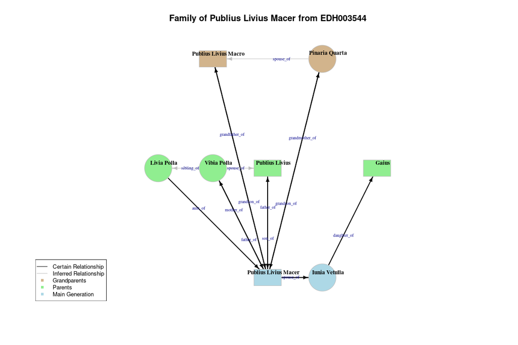

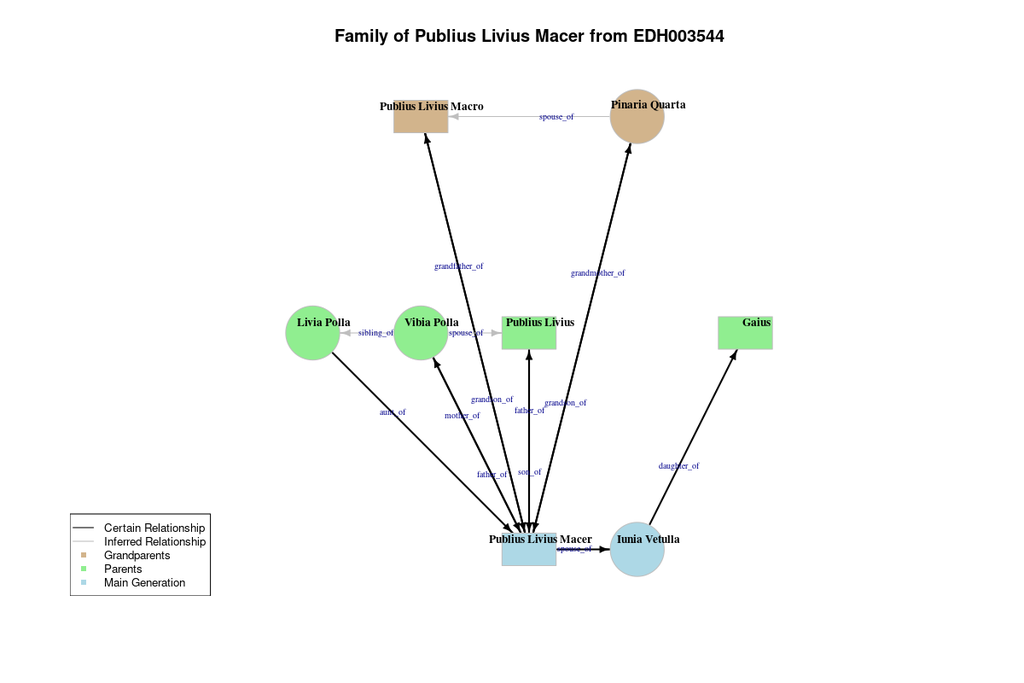

### 2.8.2 Exercise 2 (Advanced): Reconstruct the inferred people and relationships

First, let’s discuss the following scenarios from the methodological point of view. How would you go about it?

1. What does the name of Pinaria Quarta suggests? *Hint - try to reconstruct missing siblings Pinaria Prima, Pinaria Secunda, Pinaria Tertia.*
2. The same applies for siblings of Sextus. What are your assumptions?
3. How would you go about reconstructing the missing, yet biologically prerequisite, men and women, such as wife of Gaius, wife of Sextus, or parents of Sextus?

Once you have identified the people and their relationships, you can add them and try to visualise them.

```r
# work here
```

# 3 Case study 2 - Network of Clodii family from Pompeii

## 3.1 The family and its context

Most of the Clodii family derives from A. Clodius M. f., tribe Palatina, who might have come from Rome or Puteoli (Castren 1975, 154). After his marriage to the faimly of the Lassii, who were wine producers, he and his decendants engaged mainly in specialized agriculture and wine production (vinum Clodianum).

**References:**

- Wim Broekart, 2020. The Pompeian Connection: A Social Network Approach to Elites and Sub-Elites in the Bay of Naples https://jhnr.net/articles/25/files/653f546ab5567.pdf
- Paavo Castren 1975, Ordo populusque Pompeianus: polity and society in Roman Pompeii https://archive.org/details/ordopopulusquepo0008cast

I [Petra] have manually created the list of 54 people and their relationships, based on the information from 21 inscriptions, that we will now turn into a network, visualise and analyse.

## 3.2 Datasets

```r
# loading a spreadsheet into R

people3 <- read.csv("../data/Pompeii_People.csv")
people3
```

| id | name | gender | date | period | inscription_name |
| --- | --- | --- | --- | --- | --- |
| 1 | Clodius | male | 72-74, 71-75 | C | CIL 04, 00752, CIL 04, 03502, CIL 04, 03716, CIL 04, 07712, CIL 04 08168c, CIL 04, 08556 |
| 2 | M Clodius Ampliatus | male |  |  | CIL 04, 03340.66, CIL 04, 03340.97 |
| 3 | A Clodius Flaccus | male | -20–10, -2, -10-3, -27-14 | A | CIL 10, 00793, CIL 10, 00890, CIL 10, 00936, CIL 10, 00960, CIL 10, 01074d |
| 4 | Marcus Holconius Priscus | male |  |  | CIL 04, 00752 |
| 5 | Sabinus | male |  |  | CIL 04, 03716 |
| 6 | Marcus Livius Secundus | male |  |  | CIL 04, 03340.66 |
| 7 | Lucius Caecilius Iucundus | male |  |  | CIL 04, 03340.66 |
| 8 | Lucius Melissaeus Fuscus | male |  |  | CIL 04, 03340.66 |
| 9 | Laelius Trophimus | male |  |  | CIL 04, 03340.66 |
| 10 | Nerius Hyginus | male |  |  | CIL 04, 03340.66 |

[output cut: 44 more lines]

```r
# loading a spreadsheet into R

relationships3 <- read.csv("../data/Pompeii_Relationships.csv")
relationships3
```

| from | to | relationship | certainty |
| --- | --- | --- | --- |
| 1 | 4 | Supporter_of | certain |
| 4 | 1 | Supported_by | certain |
| 1 | 5 | Supporter_of | certain |
| 5 | 1 | Supported_by | certain |
| 2 | 6 | Witness_of | certain |
| 6 | 2 | Witnessed_by | certain |
| 2 | 7 | Witness_of | certain |
| 7 | 2 | Witnessed_by | certain |
| 2 | 8 | Co-witness_of | certain |
| 8 | 2 | Co-witness_of | certain |

[output cut: 74 more lines]

## 3.3 Network

```r
# Create the graph/network object (using igraph package https://igraph.org/)
inscription_network3 <- graph_from_data_frame(relationships3, directed = TRUE, vertices = people3)

# Print basic network information
print(inscription_network3)
```

```
## IGRAPH eb308b1 DN-- 54 84 --
## + attr: name (v/c), gender (v/c), date (v/c), period (v/c),
## | inscription_name (v/c), relationship (e/c), certainty (e/c)
## + edges from eb308b1 (vertex names):
##  [1] Clodius                  ->Marcus Holconius Priscus
##  [2] Marcus Holconius Priscus ->Clodius
##  [3] Clodius                  ->Sabinus
##  [4] Sabinus                  ->Clodius
##  [5] M Clodius Ampliatus      ->Marcus Livius Secundus
##  [6] Marcus Livius Secundus   ->M Clodius Ampliatus
##  [7] M Clodius Ampliatus      ->Lucius Caecilius Iucundus
## + ... omitted several edges
```

## 3.4 Visualization

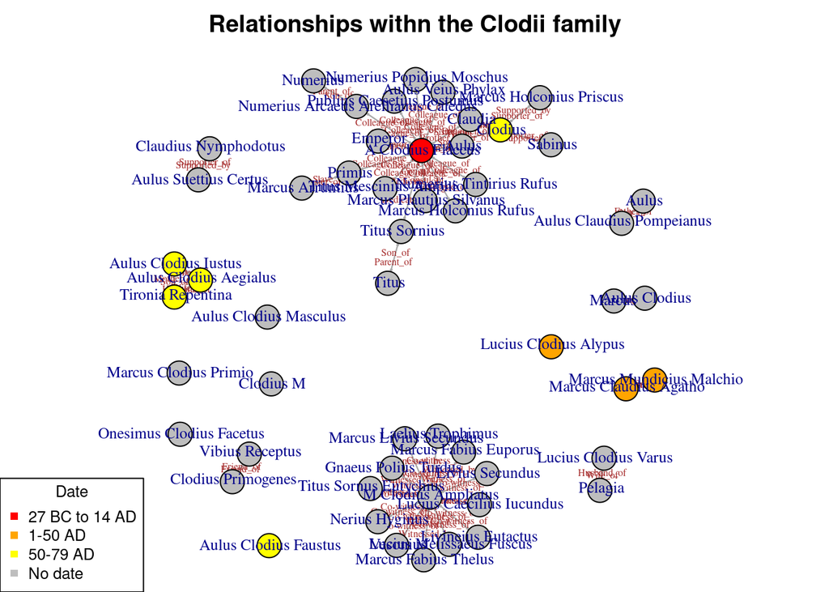

```r
# Visualizing the network using igraph package https://igraph.org/

# Set plot parameters
par(mar = c(0, 0, 2, 0))  # Adjust margins for better visualization

V(g)$color <- ifelse(V(g)$generation == 1, "tan",
                   ifelse(V(g)$generation == 2, "lightgreen", "lightblue"))

# Plot the network
plot(inscription_network3,
     vertex.label = V(inscription_network3)$name,
     vertex.color = ifelse(V(inscription_network3)$period == "A", "red",
                           ifelse(V(inscription_network3)$period == "B", "orange",
                                  ifelse(V(inscription_network3)$period == "C","yellow", "grey"))),
     vertex.size = 10,
     vertex.label.cex = 0.8,
     vertex.label.dist = 0.1,             # node label size
     vertex.label.font = 1,
     edge.arrow.size = 0.1,
     edge.label = E(inscription_network3)$relationship,
     edge.label.cex = 0.5,
     edge.label.color = "brown",
     layout = layout_with_fr(inscription_network3),
     main = "Relationships withn the Clodii family")


legend("bottomleft", title="Date",
       legend = c("27 BC to 14 AD", "1-50 AD",
                 "50-79 AD", "No date"),
       col = c("red", "orange", "yellow", "grey"),
       pch = c(15, 15, 15, 15),
       cex = 0.8,
       bg = "white")
```

```r
# save image
png("../images/ClodiusFamily.png", width = 1200, height = 800, res = 100 )
```

## 3.5 Basic network analytics

```r
# Number of vertices
num_vertices <- vcount(inscription_network3)

# Number of edges
num_edges <- ecount(inscription_network3)

# Density
density <- edge_density(inscription_network3)

# Diameter
diameter <- diameter(inscription_network3, directed = TRUE)

# Average path length
average_path_length <- mean_distance(inscription_network3, directed = TRUE)

# Clustering coefficient
clustering_coefficient <- transitivity(inscription_network3, type = "global")

# Print basic analytics
cat("Number of vertices:", num_vertices, "(The total count of unique nodes or entities in the network.)\n")
```

```
## Number of vertices: 54 (The total count of unique nodes or entities in the network.)
```

```r
cat("Number of edges:", num_edges, "(The total count of connections or relationships between the nodes in the network.)\n")
```

```
## Number of edges: 84 (The total count of connections or relationships between the nodes in the network.)
```

```r
cat("Density:", density, "(The proportion of possible connections in the network that are actually present.)\n")
```

```
## Density: 0.0293501 (The proportion of possible connections in the network that are actually present.)
```

```r
cat("Diameter:", diameter, "(The longest shortest path between any two nodes in the network.)\n")
```

```
## Diameter: 4 (The longest shortest path between any two nodes in the network.)
```

```r
cat("Average path length:", average_path_length, "(The average number of steps along the shortest paths for all possible pairs of nodes in a network, indicating how closely connected the nodes are.)\n")
```

```
## Average path length: 2.140794 (The average number of steps along the shortest paths for all possible pairs of nodes in a network, indicating how closely connected the nodes are.)
```

```r
cat("Clustering coefficient:", clustering_coefficient, "(The degree to which nodes in the network tend to cluster together.)\n")
```

```
## Clustering coefficient: 0.05202312 (The degree to which nodes in the network tend to cluster together.)
```

## 3.6 Centrality measures

```r
# Calculate centrality measures
degree_centrality <- degree(inscription_network3)
betweenness_centrality <- betweenness(inscription_network3)
closeness_centrality <- closeness(inscription_network3)
eigenvector_centrality <- eigen_centrality(inscription_network3)$vector
```

### 3.6.1 Degree Centrality

```r
# Print centrality measures
cat("Degree Centrality:\n", degree_centrality, "\n")
```

```
## Degree Centrality:
##  8 24 28 2 2 2 2 2 2 2 2 2 2 2 2 2 2 4 4 2 2 2 2 4 2 2 2 2 2 2 4 2 6 2 2 2 2 0 0 0 2 2 0 0 2 2 0 2 2 2 2 4 4 4
```

*Definition:* Measures the number of direct connections a node has.

### 3.6.2 Betweenness Centrality

```r
cat("Betweenness Centrality:\n", betweenness_centrality, "\n")
```

```
## Betweenness Centrality:
##  70 132 319 0 0 0 0 0 0 0 0 0 0 0 0 0 0 0 36 0 0 0 0 36 0 0 0 0 0 0 36 0 3 0 0 0 0 0 0 0 0 0 0 0 0 0 0 0 0 0 0 0 0 0
```

*Definition:* Measures the extent to which a node lies on paths between other nodes.

### 3.6.3 Closeness Centrality

```r
cat("Closeness Centrality:\n", closeness_centrality, "\n")
```

```
## Closeness Centrality:
##  0.02702703 0.08333333 0.04166667 0.01818182 0.01818182 0.04347826 0.04347826 0.04347826 0.04347826 0.04347826 0.04347826 0.04347826 0.04347826 0.04347826 0.04347826 0.04347826 0.04347826 0.02439024 0.025 0.01724138 0.02380952 0.02380952 0.02380952 0.025 0.01724138 0.02380952 0.02380952 0.0238095…
```

*Definition:* Measures how close a node is to all other nodes in the network.

### 3.6.4 Eigenvector Centrality

```r
cat("Eigenvector Centrality:\n", eigenvector_centrality, "\n")
```

```
## Eigenvector Centrality:
##  0.4109963 2.491624e-15 1 0.1025604 0.1025604 6.436696e-16 6.851966e-16 6.955784e-16 6.644331e-16 6.748149e-16 6.540513e-16 6.955784e-16 7.059602e-16 6.851966e-16 6.955784e-16 7.371055e-16 6.540513e-16 0.3598103 0.2661119 0.06640581 0.2495409 0.2495409 0.2495409 0.2661119 0.06640581 0.2495409 0.2…
```

*Definition:* Measures the influence of a node in the network, considering the influence of its neighbors.

```r
# Assuming eigenvector_centrality and betweenness_centrality are vectors with names corresponding to nodes
most_influential_eigenvector <- names(which.max(eigenvector_centrality))
most_influential_betweenness <- names(which.max(betweenness_centrality))

cat("Most influential person based on Eigenvector Centrality:", most_influential_eigenvector, "\n")
```

```
## Most influential person based on Eigenvector Centrality: A Clodius Flaccus
```

```r
cat("Most influential person based on Betweenness Centrality:", most_influential_betweenness, "\n")
```

```
## Most influential person based on Betweenness Centrality: A Clodius Flaccus
```

## 3.7 Hypothetical scenario

What happens if we add a hypothetical connection between Clodius (1) and M Clodius Ampliatus (2). Let’s say they were cousins (conjectured).

Edit in the CSV file, save as `Pompeii_Relationships_hypothetical.csv` and load it into R.

```r
relationships4 <- read.csv("../data/Pompeii_Relationships_hypothetical.csv")
```

Create a network

```r
# Create the graph/network object (using igraph package https://igraph.org/)
inscription_network4 <- graph_from_data_frame(relationships4, directed = TRUE, vertices = people3)

# Print basic network information
print(inscription_network4)
```

```
## IGRAPH ad5610f DN-- 54 86 --
## + attr: name (v/c), gender (v/c), date (v/c), period (v/c),
## | inscription_name (v/c), relationship (e/c), certainty (e/c)
## + edges from ad5610f (vertex names):
##  [1] Clodius                  ->Marcus Holconius Priscus
##  [2] Marcus Holconius Priscus ->Clodius
##  [3] Clodius                  ->Sabinus
##  [4] Sabinus                  ->Clodius
##  [5] M Clodius Ampliatus      ->Marcus Livius Secundus
##  [6] Marcus Livius Secundus   ->M Clodius Ampliatus
##  [7] M Clodius Ampliatus      ->Lucius Caecilius Iucundus
## + ... omitted several edges
```

Now let’s have a look what it does to our network!

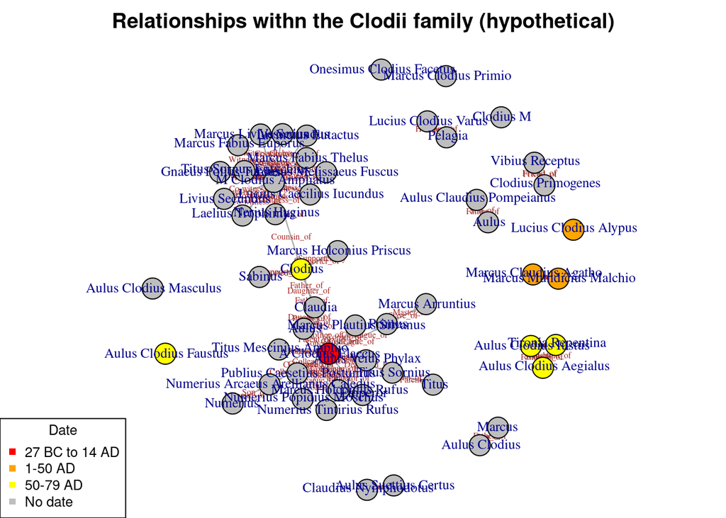

```r
# Visualizing the network using igraph package https://igraph.org/

# Set plot parameters
par(mar = c(0, 0, 2, 0))  # Adjust margins for better visualization

V(g)$color <- ifelse(V(g)$generation == 1, "tan",
                   ifelse(V(g)$generation == 2, "lightgreen", "lightblue"))

# Plot the network
plot(inscription_network4,
     vertex.label = V(inscription_network4)$name,
     vertex.color = ifelse(V(inscription_network4)$period == "A", "red",
                           ifelse(V(inscription_network4)$period == "B", "orange",
                                  ifelse(V(inscription_network4)$period == "C","yellow", "grey"))),
     vertex.size = 10,
     vertex.label.cex = 0.8,
     vertex.label.dist = 0.1,             # node label size
     vertex.label.font = 1,
     edge.arrow.size = 0.1,
     edge.label = E(inscription_network4)$relationship,
     edge.label.cex = 0.5,
     edge.label.color = "brown",
     layout = layout_with_fr(inscription_network4),
     main = "Relationships withn the Clodii family (hypothetical)")


legend("bottomleft", title="Date",
       legend = c("27 BC to 14 AD", "1-50 AD",
                 "50-79 AD", "No date"),
       col = c("red", "orange", "yellow", "grey"),
       pch = c(15, 15, 15, 15),
       cex = 0.8,
       bg = "white")
```

```r
# save image
png("../images/ClodiusFamily_hypothetical.png", width = 1200, height = 800, res = 100 )
```

Now, let’s compare both networks:

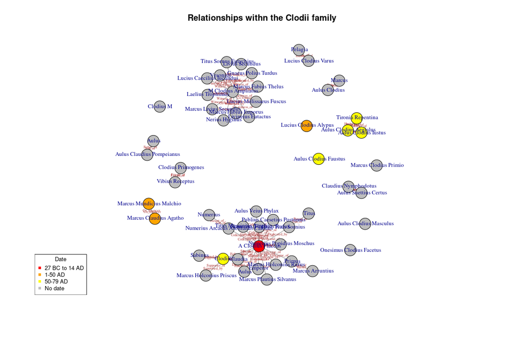

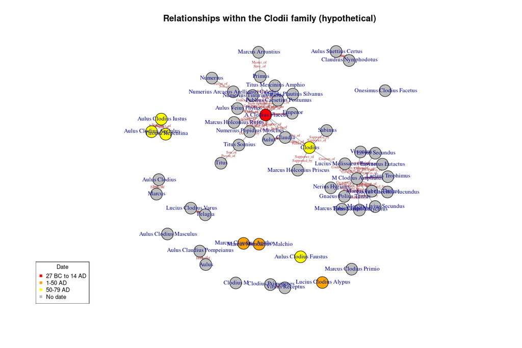

Let’s see how some of the analytical data change:

```r
eigenvector_centrality2 <- eigen_centrality(inscription_network4)$vector


cat("Original Eigenvector Centrality:\n", eigenvector_centrality, "\n")
```

```
## Original Eigenvector Centrality:
##  0.4109963 2.491624e-15 1 0.1025604 0.1025604 6.436696e-16 6.851966e-16 6.955784e-16 6.644331e-16 6.748149e-16 6.540513e-16 6.955784e-16 7.059602e-16 6.851966e-16 6.955784e-16 7.371055e-16 6.540513e-16 0.3598103 0.2661119 0.06640581 0.2495409 0.2495409 0.2495409 0.2661119 0.06640581 0.2495409 0.2…
```

```r
cat("Hypothetical Eigenvector Centrality:\n", eigenvector_centrality2, "\n")
```

```
## Hypothetical Eigenvector Centrality:
##  0.5343918 0.4620234 1 0.1306466 0.1306466 0.1129542 0.1129542 0.1129542 0.1129542 0.1129542 0.1129542 0.1129542 0.1129542 0.1129542 0.1129542 0.1129542 0.1129542 0.3575574 0.2600183 0.06356855 0.2444772 0.2444772 0.2444772 0.2600183 0.06356855 0.2444772 0.2444772 0.2444772 0.2444772 0.2444772 0.…
```

Commentary: Adding the hypothetical connection between Clodius and M Clodius Ampliatus increases their centrality, making them more influential in the network.

```r
# Find the person with the highest eigenvector centrality
eigenvector_centrality %>%
  sort(decreasing = TRUE)
```

```
##                   A Clodius Flaccus                             Claudia
##                        1.000000e+00                        4.418887e-01
##                             Clodius                               Aulus
##                        4.109963e-01                        3.598103e-01
##                       Titus Sornius Numerius Arcaeus Arellianus Caledus
##                        2.661119e-01                        2.661119e-01
##                              Primus                             Emperor
##                        2.661119e-01                        2.495409e-01
##           Numerius Popidius Moschus              Titus Mescinius Amphio
##                        2.495409e-01                        2.495409e-01
##          Publius Caesetius Postumus            Numerius Tintirius Rufus
##                        2.495409e-01                        2.495409e-01
##                  Aulus Veius Phylax              Marcus Holconius Rufus
##                        2.495409e-01                        2.495409e-01
##            Marcus Plautius Silvanus            Marcus Holconius Priscus
##                        2.495409e-01                        1.025604e-01
##                             Sabinus                           Numerius
##                        1.025604e-01                        6.640581e-02
##                    Marcus Arruntius                               Titus
##                        6.640581e-02                        6.640581e-02
##                 M Clodius Ampliatus                Marcus Fabius Thelus
##                        2.491624e-15                        7.371055e-16
##                     Livius Secundus            Lucius Melissaeus Fuscus
##                        7.059602e-16                        6.955784e-16
##                  Livineius Eutactus                Gnaeus Polius Turdus
##                        6.955784e-16                        6.955784e-16
##           Lucius Caecilius Iucundus                            Vesonius
##                        6.851966e-16                        6.851966e-16
##                      Nerius Hyginus                   Laelius Trophimus
##                        6.748149e-16                        6.644331e-16
##              Titus Sornus Eutychius               Marcus Fabius Euporus
##                        6.540513e-16                        6.540513e-16
##              Marcus Livius Secundus                   Tironia Repentina
##                        6.436696e-16                        2.076353e-16
##              Aulus Clodius Aegialus                Aulus Clodius Iustus
##                        1.868718e-16                        1.661083e-16
##                  Clodius Primogenes               Aulus Suettius Certus
##                        1.038177e-16                        9.343590e-17
##                Lucius Clodius Varus                             Pelagia
##                        9.343590e-17                        9.343590e-17
##                             Marcus             Marcus Mundicius Malchio
##                        8.305414e-17                        8.305414e-17
##                Claudius Nymphodotus                     Vibius Receptus
##                        7.267237e-17                        7.267237e-17
##                       Aulus Clodius           Aulus Claudius Pompeianus
##                        7.267237e-17                        7.267237e-17
##              Marcus Claudius Agatho                               Aulus
##                        7.267237e-17                        6.229060e-17
##               Lucius Clodius Alypus              Aulus Clodius Masculus
##                        2.076353e-17                        2.076353e-17
##               Marcus Clodius Primio            Onesimus Clodius Facetus
##                        2.076353e-17                        2.076353e-17
##                           Clodius M               Aulus Clodius Faustus
##                        2.076353e-17                        2.076353e-17
```

```r
eigenvector_centrality2 %>%
  sort(decreasing = TRUE)
```

```
##                   A Clodius Flaccus                             Clodius
##                        1.000000e+00                        5.343918e-01
##                             Claudia                 M Clodius Ampliatus
##                        4.625385e-01                        4.620234e-01
##                               Aulus Numerius Arcaeus Arellianus Caledus
##                        3.575574e-01                        2.600183e-01
##                              Primus                       Titus Sornius
##                        2.600183e-01                        2.600183e-01
##           Numerius Popidius Moschus                  Aulus Veius Phylax
##                        2.444772e-01                        2.444772e-01
##              Titus Mescinius Amphio          Publius Caesetius Postumus
##                        2.444772e-01                        2.444772e-01
##            Numerius Tintirius Rufus            Marcus Plautius Silvanus
##                        2.444772e-01                        2.444772e-01
##              Marcus Holconius Rufus                             Emperor
##                        2.444772e-01                        2.444772e-01
##                             Sabinus            Marcus Holconius Priscus
##                        1.306466e-01                        1.306466e-01
##            Lucius Melissaeus Fuscus                      Nerius Hyginus
##                        1.129542e-01                        1.129542e-01
##                Marcus Fabius Thelus           Lucius Caecilius Iucundus
##                        1.129542e-01                        1.129542e-01
##                     Livius Secundus                            Vesonius
##                        1.129542e-01                        1.129542e-01
##                Gnaeus Polius Turdus              Marcus Livius Secundus
##                        1.129542e-01                        1.129542e-01
##                   Laelius Trophimus              Titus Sornus Eutychius
##                        1.129542e-01                        1.129542e-01
##               Marcus Fabius Euporus                  Livineius Eutactus
##                        1.129542e-01                        1.129542e-01
##                               Titus                    Marcus Arruntius
##                        6.356855e-02                        6.356855e-02
##                           Numerius                 Aulus Clodius Iustus
##                        6.356855e-02                        4.578555e-17
##                   Tironia Repentina              Aulus Clodius Aegialus
##                        4.578555e-17                        2.289278e-17
##               Lucius Clodius Alypus              Aulus Clodius Masculus
##                        5.723194e-18                        5.723194e-18
##               Marcus Clodius Primio            Onesimus Clodius Facetus
##                        5.723194e-18                        5.723194e-18
##                           Clodius M               Aulus Clodius Faustus
##                        5.723194e-18                        5.723194e-18
##                Claudius Nymphodotus               Aulus Suettius Certus
##                        0.000000e+00                        0.000000e+00
##                  Clodius Primogenes                     Vibius Receptus
##                        0.000000e+00                        0.000000e+00
##                Lucius Clodius Varus                             Pelagia
##                        0.000000e+00                        0.000000e+00
##                       Aulus Clodius                             Marcus
##                        0.000000e+00                        0.000000e+00
##           Aulus Claudius Pompeianus                               Aulus
##                        0.000000e+00                        0.000000e+00
##            Marcus Mundicius Malchio              Marcus Claudius Agatho
##                        0.000000e+00                        0.000000e+00
```

Similarly, we can compare other analytical results.

Let’s look at Betweenness centrality:

```r
# work here
```

# 4 Resources

For more resources and practical exercises in SNA in historical and archaeological data, please see:

`Brughmans, Tom, and Matthew A. Peeples. Network Science in Archaeology. of Cambridge Manuals in Archaeology. Cambridge: Cambridge University Press, 2023. https://doi.org/10.1017/9781009170659`

The online appendix and exercises are available via https://archnetworks.net/

## 4.1 Resources by The Barcelona Past Networks Summer School community https://www.pastnetworks.net/

### 4.1.1 Conferences

#### 4.1.1.1 Past Networks

- Connected Past (https://connectedpast.net/)
- The Historical Network Research Conference (https://historicalnetworkresearch.org/hnr-events/; 2024: https://historicalnetworkresearch.github.io/lausanne/)

#### 4.1.1.2 Network science and complex systems

- Conference on Complex Systems (https://cssociety.org/ccs)
- NetSci and NetSci-X (https://netscisociety.net/home)

#### 4.1.1.3 Social Network analysis

- INSNA Sunbelt Conference (https://www.insna.org/)
- European Social Network Conference – EUSN (https://www.insna.org/european-conference-of-social-networks-eusn)
- International Conference on Computational Social Science (https://ic2s2.org/)

#### 4.1.1.4 Digital Humanities

- Computational Humanities Research (2024: https://2024.computational-humanities-research.org/cfp/)
- Digital Humanities Conference (https://adho.org/conference/)
- Computer Applications in Archaeology (https://caa-international.org/)

### 4.1.2 Journals

- The Journal of Historical Network Research (https://jhnr.net/)
- Digital Scholarship in the Humanities (https://academic.oup.com/dsh)
- Social Networks (https://www.sciencedirect.com/journal/social-networks)
- Journal of Computer Applications in Archaeology (https://journal.caa-international.org/)
- Journal of Digital History (https://journalofdigitalhistory.org/)
- Redes (https://revistes.uab.cat/redes)

### 4.1.3 Tutorials

- Online resources for The Cambridge Manual of Network Science in Archaeology: includes exhaustive tutorials in R on all aspects of past network research (https://book.archnetworks.net/)
- Uncertainty in networks
- Spatial networks
- ERGMs
- Spatial interaction models
- Affiliation networks
- Network diffusion
- Comparing networks
- Dozens of tutorials are listed in the HNR website (https://historicalnetworkresearch.org/external-resources/)
- Archaeological network data and network analysis scripts by Matt Peeples: (https://mattpeeples.net/data-and-software/)
- Archaeological network research tutorials by Tom Brughmans (https://archaeologicalnetworks.wordpress.com/)
- The Vistorian tutorial
- Visone tutorial
- Cytoscape tutorial
- Netlogo tutorial
- GEPHI - Introduction to Network Analysis and Visualization, Gephi tutorial by Martin Grandjean (with video https://www.martingrandjean.ch/gephi-introduction/)
- Interactive explorable explanations of network concepts:
- The wisdom and/or madness of crowds (about alcohol consumption) (https://ncase.me/crowds/)
- Cats VS dogs (https://vis.csh.ac.at/planets-of-disparity/)
- Transmission of viruses through social networks (about COVID) (http://www.r2d3.us/covid-19/)
- An introduction class to graph theory (maths) (https://d3gt.com)
- From Hermeneutics to Data to Networks Data Extraction and Network Visualization of Historical Sources, lesson by Marten Düring in Programming Historian (https://programminghistorian.org/en/lessons/creating-network-diagrams-from-historical-sources)

### 4.1.4 Tools

- R (https://www.r-project.org/)
- R Studio (https://posit.co/products/open-source/rstudio/)
- igraph (https://r.igraph.org/)
- ggplot2 (https://ggplot2.tidyverse.org/)
- Gephi (https://gephi.org/)
- Blog (https://gephi.wordpress.com/)
- Nodegoat (https://nodegoat.net/)
- Vistorian (https://vistorian.github.io/vistorian/)
- Python (https://www.python.org/)

### 4.1.5 Communities

- The Barcelona Past Networks Summer School (https://www.pastnetworks.net/ )
- The Historical Network Research Community (https://historicalnetworkresearch.org/)
- The Connected Past (https://connectedpast.net/)
- Computer applications in archaeology (https://caa-international.org/)
- Réseaux et Histoire (https://reshist.hypotheses.org/)
- Complexitat.cat (https://complexitat.cat/)
- Alliance of digital humanities organisations (https://adho.org/)

### 4.1.6 Data

- All datasets from the Cambridge Manual of Network Science in Archaeology (https://book.archnetworks.net/dataandworkspace)
- “Intellectual Cooperation”, a network dataset based on Martin’s archives (https://github.com/grandjeanmartin/intellectual-cooperation)
- “Moreno’s Sociograms”, a series of small datasets to remake the famous sociograms of 1934 (https://github.com/grandjeanmartin/sociograms)
- Open datasets in Roman Studies (https://projectmercury.eu/datasets/)
- Netzschleuder: a (non-historical) network dataset repository (more than 100k networks https://networks.skewed.de/)

### 4.1.7 Literature

- Exhaustive bibliography on HNR Zotero (https://www.zotero.org/groups/209983/historical_network_research)
- All archaeological networks Zotero bibliography (https://www.zotero.org/groups/824994/archaeologicalnetworks)
- Network Science in Archaeology by Tom Brughmans and Matthew A. Peeples (2023)(https://book.archnetworks.net/)

### 4.1.8 Other links

- The Digital Humanities Literacy Guidebook: with links to many educational resources (https://cmu-lib.github.io/dhlg/)
- Introduction to Social Network Analysis: Basics and Historical Specificities, video series ▶️by Martin Grandjean for HNR (https://www.martingrandjean.ch/introduction-to-social-network-analysis/)
- Free open manual in network science by Michele Coscia (https://www.networkatlas.eu/)
- “Translating Networks”, a short conference paper by Martin Grandjean and Mathieu Jacomy (Gephi creator) which discusses how to “translate” measures of centrality into the language of the humanities and social sciences. See in particular the appendix, which contains a long list of interpretation scenarios. (https://shs.hal.science/halshs-02179024v1/document)
- “Intersubjective Networks”, a funny experiment with videos ▶️by Martin Grandjean and Mathieu Jacomy to see if two researchers with the same network dataset would “see” the same thing (https://intersubjective-networks.github.io/dh2022/)
- The HNR YouTube channel, with video recordings ▶️of online lectures (https://www.youtube.com/@HistoricalNetworkResearch)
[^1]: Aarhus University, Denmark, https://orcid.org/0000-0002-6349-0540
[^2]: Aarhus University, Denmark, https://orcid.org/0000-0002-1589-7768